# MyZone Data Exploration

Marc Fletcher

29 January 2019

# MyZone Challenge

My local gym sells the MyZone MZ-3 fitness trackers and sets up regular competitions for the members who have purchased a tracker. These challenges are team based and have some very simple rules:

- The team that accumulates the most MyZone Energy Points (MEPs) in the month wins,
- Only one workout per-person per-day will count towards the team total.

The MyZone fitness tracker is worn across the chest and awards MEPs for each minute of activity based on which of 5 zones the users heart rate is in. These zones are based on the users maximum theoretical heart-rate ($220 - age$ beats per minute):

- 40-49% for 0 MEPs per-minute,
- 50-59% for 1 MEP per-minute,
- 60-69% for 2 MEPs per-minute,
- 70-79% for 3 MEPs per-minute,
- 80-89% for 4 MEPs per-minute,
- 90-100% for 6 MEPs per-minute.

I had my first competition in September of last year and I found the experience to be a very good source of (temporary) motivation. The competition ran for all 30 days of September and I did some kind of workout for 25 of those days (a combination of walking and working out at the gym), contributing 6,409 MEPs to the team total. The next competition begins in February and I hope to obtain a similar total, however this time I only have 28 days to do it.

# MyZone Data

The MyZone website makes your workout data available to you via a not so intuitive user portal. Data for each day can be downloaded as a CSV file that contains two tables, one containing a single line summary of the workout (i.e. total MEPs, time in each zone etc.) and the other table contains the average heart-rate for each minute of the workout. The data can be downloaded for a range of dates and the resulting CSV file appears to just be a concatenated version of the data for each day in the range.

- Data cleaning notes

```
## # A tibble: 6 x 23
##   Date  Start End   description `Average Effort` `Average Heart ~  MEPs
##   <chr> <chr> <chr> <chr>                  <dbl>            <dbl> <dbl>
## 1 2018~ 16:29 17:38 Workout                 0.56              109    87
## 2 2018~ 19:20 20:57 Jesse sess~             0.68              133   231
## 3 2018~ 19:24 21:30 Bit of gym~             0.74              143   372
## 4 2018~ 20:34 21:46 Walk                    0.67              131   165
## 5 2018~ 19:56 21:58 Gym and wa~             0.71              138   325
## 6 2018~ 19:32 20:21 Short walk              0.67              130   113
## # ... with 16 more variables: Duration <dbl>, `Time in Zone` <dbl>,
## #   Calories <dbl>, `Peak Heart Rate` <dbl>, `Zone 0 Mins` <dbl>, `Zone 1
## #   Mins` <dbl>, `Zone 2 Mins` <dbl>, `Zone 3 Mins` <dbl>, `Zone 4
## #   Mins` <dbl>, `Zone 5 Mins` <dbl>, `Zone 0 MEPs` <dbl>, `Zone 1
## #   MEPs` <dbl>, `Zone 2 MEPs` <dbl>, `Zone 3 MEPs` <dbl>, `Zone 4
## #   MEPs` <dbl>, `Zone 5 MEPs` <dbl>
```

The description field can be filled out for each workout and defaults to “Workout”, in my case this data has not been entered with consistency but for most of the workouts it should be possible to create some indicator variables that can be used to examine similar workouts. The workouts were sorted into one of the following typesY:

- Self - gym workout with no walking,
- PT - session with a trainer (in the gym) with no walking,
- Self+Walk - gym session and walking to/from the gym,
- PT+Walk - session with trainer and walking to/from the gym,
- Walk - just walking (no gym),
- Blitz - fitness class (no walking).

For most of the workouts the indicator variables could be populated by using R’s regular expression functions to search for keywords (e.g. Walk, Blitz etc.), however a few had to be manually updated as the description was not helpful. The following table provides a breakdown of how many workouts of each type were recorded.

```
## # A tibble: 6 x 2
##   Type        Workouts
##   <chr>          <int>
## 1 Self              24
## 2 PT                13
## 3 Self & Walk       10
## 4 PT & Walk          7
## 5 Walk               7
## 6 Blitz              4
```

# Exploring the Data

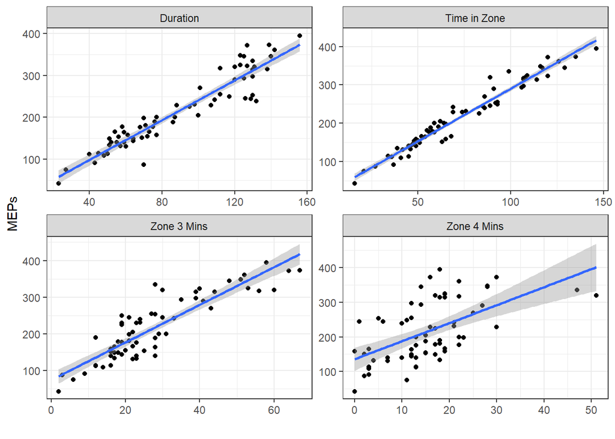

The linear relationship between total MEPs and the time in zone is shown below, note that the model retains an intercept term as the time in zone is a subset of the total workout duration and so it is expected that some small number of MEPs should be accumulated even if the time in zone is zero minutes.

```
##
## Call:
## lm(formula = MEPs ~ `Time in Zone`, data = workout)
##
## Residuals:
##     Min      1Q  Median      3Q     Max
## -37.384 -13.717   1.151   8.143  60.066
##
## Coefficients:
##                Estimate Std. Error t value Pr(>|t|)
## (Intercept)     15.0126     6.0664   2.475    0.016 *
## `Time in Zone`   2.7519     0.0765  35.974   <2e-16 ***
## ---
## Signif. codes:  0 '***' 0.001 '**' 0.01 '*' 0.05 '.' 0.1 ' ' 1
##
## Residual standard error: 18.86 on 63 degrees of freedom
## Multiple R-squared:  0.9536, Adjusted R-squared:  0.9528
## F-statistic:  1294 on 1 and 63 DF,  p-value: < 2.2e-16
```

The model shows that in general:

- Over 95% of the variation in the total MEPs can be explained by the duration of exercise with a heart rate in excess of 60% of the maximum,
- on average I earn 2.75 MEPs per minute (recall that a heart-rate between 60-69% of the maximum earns 2 MEPs per minute),
- on average 15 MEPs are accumulated with a heart-rate of less than 60% of the maximum.

The above linear model does not differentiate between workouts, i.e. minutes spent attending a Saturday morning fitness class (Blitz) are treated the same as minutes spent working out with my personal trainer or on my own. Anecdotally I would consider Blitz to involve longer periods of high intensity exercise than either my PT sessions (which are shorter) or my self-driven workouts (lower intensity and much more variable duration).

```
## # A tibble: 6 x 4
##   Type        `Num. Sessions` `Avg. Effort Adj.` `Avg. Excess MEPs`
##   <chr>                 <int>              <dbl>              <dbl>
## 1 Blitz                     4               0.78               37.6
## 2 PT                       13               0.71                8.2
## 3 Self                     24               0.68               -1
## 4 PT & Walk                 7               0.48               -3.1
## 5 Self & Walk              10               0.56               -3.8
## 6 Walk                      7               0.32              -24.8
```

To further illustrate, the following plot shows the distribution of the model residuals for each workout type.

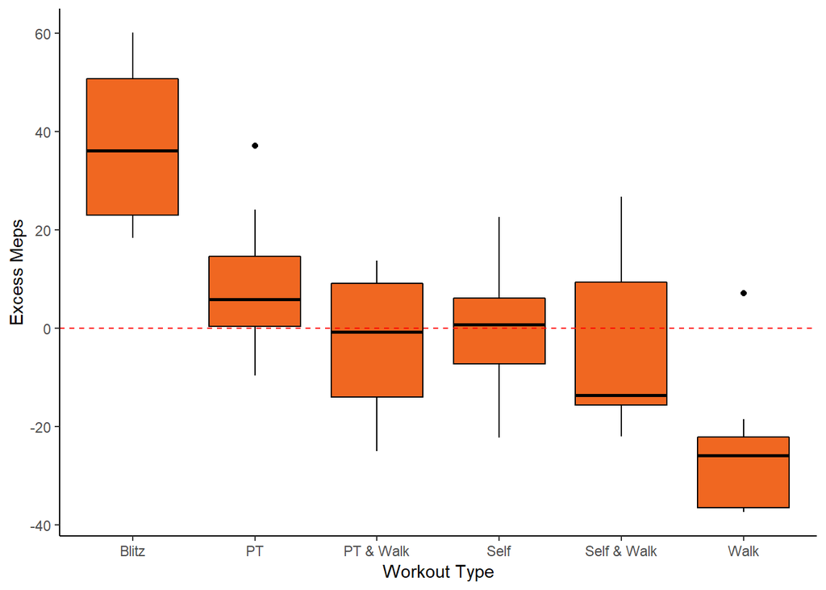

including the workout type in the model as a factor variable

```
## Linear mixed model fit by REML ['lmerMod']
## Formula: MEPs ~ 1 + ActiveDuration + (1 | Type)
##    Data: workout
##
## REML criterion at convergence: 539.9
##
## Scaled residuals:
##     Min      1Q  Median      3Q     Max
## -1.5188 -0.7351 -0.1511  0.6236  2.2126
##
## Random effects:
##  Groups   Name        Variance Std.Dev.
##  Type     (Intercept) 378.0    19.44
##  Residual             194.3    13.94
## Number of obs: 65, groups:  Type, 6
##
## Fixed effects:
##                Estimate Std. Error t value
## (Intercept)    20.44024   10.33107   1.979
## ActiveDuration  2.70778    0.07882  34.354
##
## Correlation of Fixed Effects:
##             (Intr)
## ActiveDurtn -0.610
```

The model shows that in general:

- 66% of the variation in the MEPs can be explained by the workout type,
- on average I earn 2.71 MEPs per minute (indicating an average effort level of 67.08%),
- on average 20.44 MEPs are accumulated during time where my heart rate is below 60% of the maximum.

Using all of the above data I can begin to formulate a workout plan.

# Workout Plan

So for 1 Blitz session, 1 PT session and 4 self-directed sessions the projected weekly accumulation will be 1200 MEPs, which will make for 4800 MEPs for the entire competition (far short of my stated goal of 6409). Increasing self-directed workout duration to 90 minutes raises the total MEPs to 6240 MEPs…oh boy.